# Climate Change Module

Author

Aum Patel

```r
library(tidyverse)
```

## Warm-up: Examining CO2 trends in R

- Example from http://climate.nasa.gov/vital-signs/carbon-dioxide/
- Raw data from https://gml.noaa.gov/webdata/ccgg/trends/co2/co2_mm_mlo.txt

In 1958, Dr. Charles David Keeling (1928-2005), a scientist at Scripps Institute of Oceanography, began collecting data on atmospheric CO2 concentration at the Mauna Loa Observatory located in Hawaii. This dataset allowed us to understand the degree to which climate change is human-caused through our burning of fossil fuels and release of CO2 into the atmosphere. Due to his scientific achievements, Dr. Keeling was awarded the National Medal of Science by President George W. Bush in 2002. This is the highest award for lifetime scientific achievement that can be granted in the U.S. Today, you get to analyze this same dataset, except that you have more data than was available to Dr. Keeling and his colleagues because your dataset extends up to the current time.

To read the code, you will use a new function called `read_table`. It is similar to `read_csv` except it looks for spaces between column entries rather than commas (remember that csv stands for comma-separated values). Others include `read_tsv`, which uses tabs to separate entries. You can discover the separation type by putting https://gml.noaa.gov/webdata/ccgg/trends/co2/co2_mm_mlo.txt into your web browser and examining the file. The code also includes an argument for comment, which denotes the character used to define a line in the file as being a comment rather than data or a header. The file also reveals that the column headers are on lines with a comment character, so they won’t be read. You will use the argument `col_names` to define the headers manually. Finally, `NA` values are defined by the numbers -1 and -99, so they need to be defined using the `na` argument (otherwise, they will be read as numeric values).

```r
co2 <-  read_table("https://gml.noaa.gov/webdata/ccgg/trends/co2/co2_mm_mlo.txt",
                  comment="#",
                  col_names = c("year", "month", "decimal_date",
                                "monthly_average",
                                "deseasonalized", "days", "sd_days",
                                "unc_month_mean"),
                  na = c("-1", "-99.99"))
co2
```

```
# A tibble: 803 × 8
    year month decimal_date monthly_average deseasonalized  days sd_days
   <dbl> <dbl>        <dbl>           <dbl>          <dbl> <dbl>   <dbl>
 1  1958     3        1958.            316.           314.    NA   -9.99
 2  1958     4        1958.            317.           315.    NA   -9.99
 3  1958     5        1958.            318.           315.    NA   -9.99
 4  1958     6        1958.            317.           315.    NA   -9.99
 5  1958     7        1959.            316.           315.    NA   -9.99
 6  1958     8        1959.            315.           316.    NA   -9.99
 7  1958     9        1959.            313.           316.    NA   -9.99
 8  1958    10        1959.            312.           315.    NA   -9.99
 9  1958    11        1959.            313.           315.    NA   -9.99
10  1958    12        1959.            315.           315.    NA   -9.99
# ℹ 793 more rows
# ℹ 1 more variable: unc_month_mean <dbl>
```

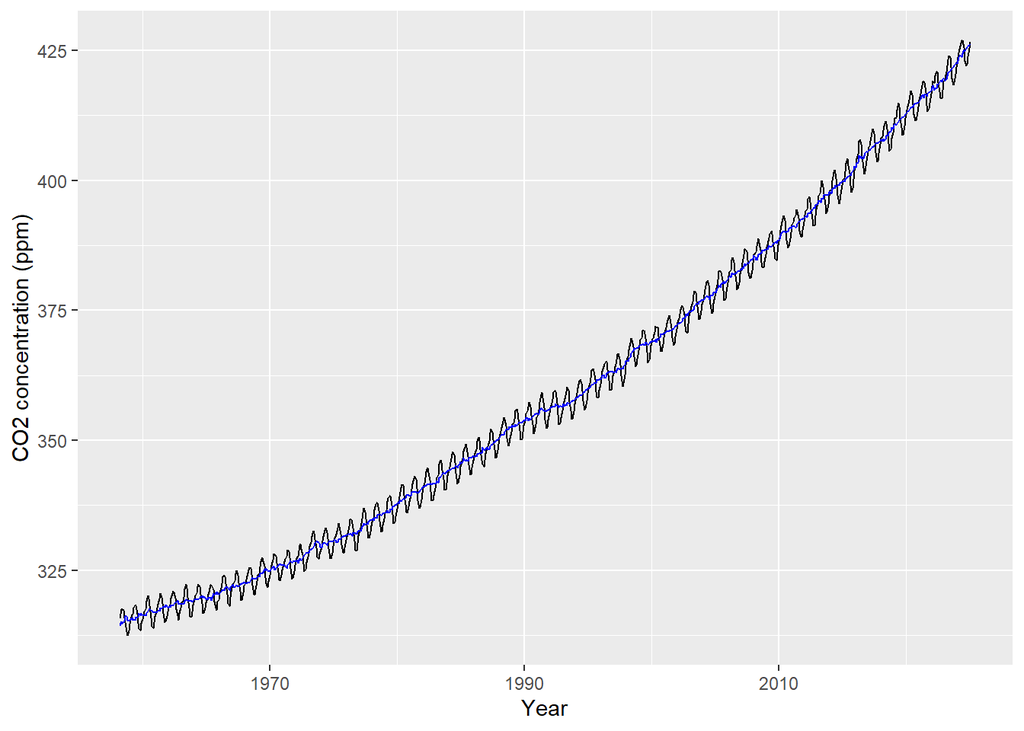

```r
ggplot(co2, aes(x = decimal_date, y = monthly_average)) +
  geom_line() +
  geom_line(aes(y = deseasonalized), color = "blue") +
  labs(x = "Year", y = "CO2 concentration (ppm)")
```

**Question 1:**

Describe the overall trend in the CO2 data.

**Answer 1:**

**Question 2:**

How does CO2 vary within a year? What month is it at max? Min? What might explain this sub-annual pattern? (you will need to write code and make a plot to answer this question)

**Answer 2:**

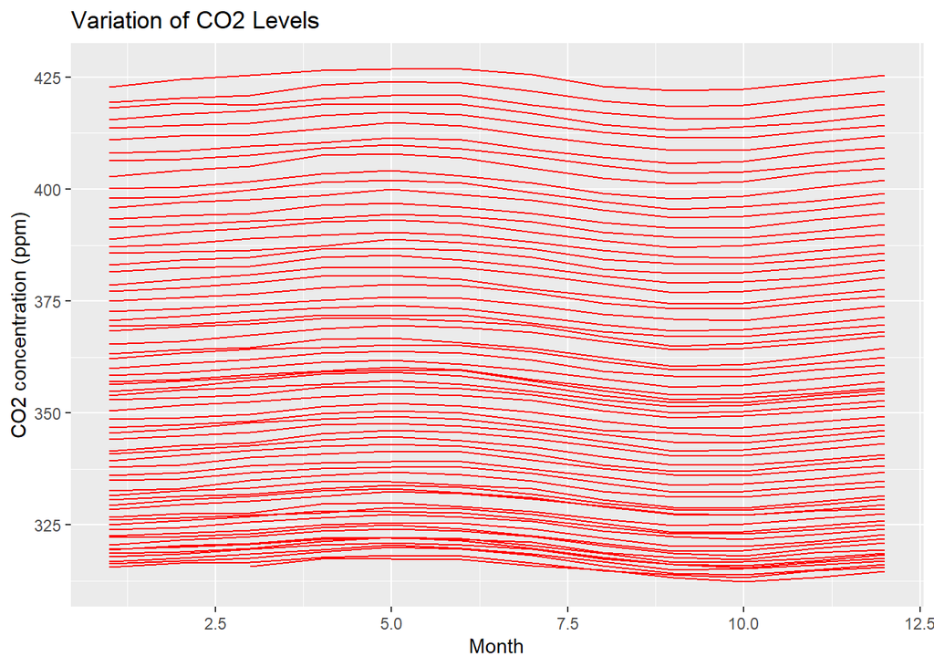

```r
ggplot(co2, aes(x = month, y = monthly_average, group = year)) +
  geom_line() +
  stat_summary(fun = mean, geom = "line", color = "red") +
  labs(x = "Month", y = "CO2 concentration (ppm)", title = "Variation of CO2 Levels")
```

The highest levels are in May and the lowest are around September. The CO2 levels most likely vary because of photosynthetic rates. When plants release CO2 in the fall and winter, they steadily increase.

## Global Temperature Data

Current climate change affects many aspects of the environment, with socio-economic consequences. For example, a warmer climate can allow new diseases to be introduced and persist (e.g., West Nile became established in the United States after an unusually warm winter, which allowed the mosquitoes that carry the virus to survive and spread). We are concerned not only with the actual temperature but also with the rate at which it changes. Rapid changes make it more likely that species cannot adapt and will go extinct.

Each of the most recent years has been the warmest on record. In this section, we will analyze global mean temperature data.

Data from: https://climate.nasa.gov/vital-signs/global-temperature/

**Question 3:**

Describe the data set to the best of your ability, given the documentation provided.

- Where is the data from?
- Describe the class of each column and what units it is measured in.
- What is the difference between “global temperature” and “global temperature anomaly”?

**Answer 3:** The data is from NASA’s Goddard Institute for Space Studies. The columns are the calendar year and the difference in temperature from the norm. Global temp is the temperature of the the planet and global temperature anomaly is the difference from the mean temperature based on trends.

**Question 4:**

Construct the necessary R code to import and prepare for plotting the following data set: https://data.giss.nasa.gov/gistemp/graphs/graph_data/Global_Mean_Estimates_based_on_Land_and_Ocean_Data/graph.txt

You’ll need to determine the file’s delimiter and any comments or skips. You will also need to be sure that you have column names. You will not directly use the code above to read the CO2 data, but that code provides helpful tips for reading the data.

**Answer 4:**

```r
url <- "https://data.giss.nasa.gov/gistemp/graphs/graph_data/Global_Mean_Estimates_based_on_Land_and_Ocean_Data/graph.txt"

global_temp <- read_table(url,
                          col_names = c("Year", "No_Smoothing", "Lowess_5"),
                          col_types = cols(
                            Year = col_integer(),
                            No_Smoothing = col_double(),
                            Lowess_5 = col_double()
                          ),
                          skip = 5)
```

**Question 5:**

Plot the trend in global mean temperatures over time. Describe what you see in the plot and how you interpret the patterns you observe.

**Answer 5:**

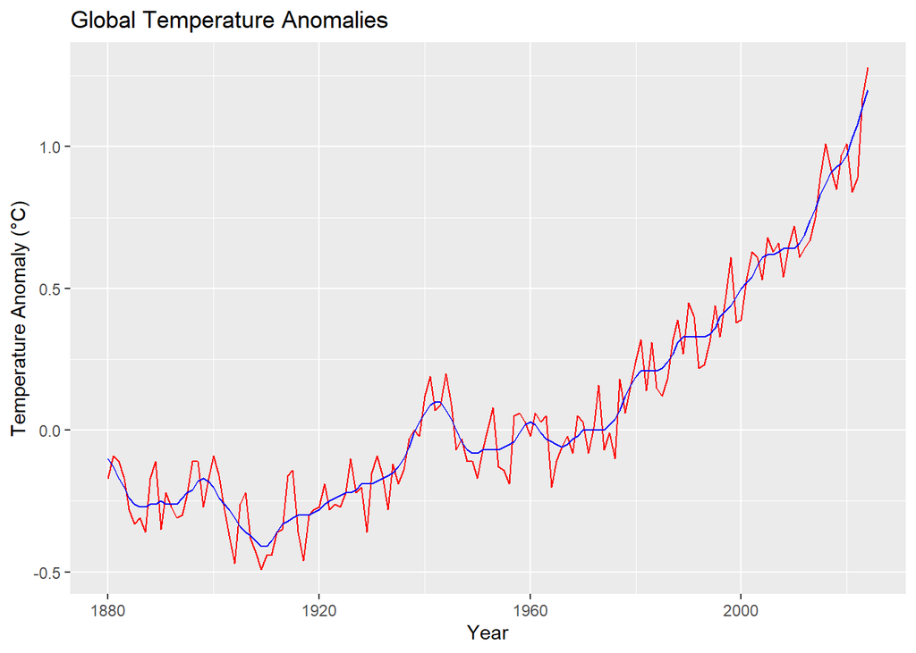

```r
ggplot(global_temp, aes(x = Year)) +
  geom_line(aes(y = No_Smoothing), color = "red") +
  geom_line(aes(y = Lowess_5), color = "blue") +
  labs(x = "Year", y = "Temperature Anomaly (°C)",
       title = "Global Temperature Anomalies")
```

Based on the plot, the temperatures have increased at a fast rate. This graph shows the global warming trends.

## Evaluating the evidence for a “Pause” in warming?

The [2013 IPCC Report](https://www.ipcc.ch/pdf/assessment-report/ar5/wg1/WG1AR5_SummaryVolume_FINAL.pdf) included a tentative observation of a “much smaller increasing trend” in global mean temperatures since 1998 than was observed previously. This led to much discussion in the media about the existence of a “Pause” or “Hiatus” in global warming rates, as well as much research looking into where the extra heat could have gone. (Examples discussing this question include articles in [The Guardian](http://www.theguardian.com/environment/2015/jun/04/global-warming-hasnt-paused-study-finds), [BBC News](http://www.bbc.com/news/science-environment-28870988), and [Wikipedia](https://en.wikipedia.org/wiki/Global_warming_hiatus)).

You will use rolling averages to help you explore the evidence for a pause. Since you have not been provided instructions for calculating rolling means, the learning objective of this question is to practice finding the solution.

**Question 6:**

Use a search engine (e.g., Google) or a chat LLM to find out how to calculate a rolling average in R. What search term or chat LLM prompt did you use? What website or answer from the chat LLM did you end up using? How much did you need to modify the code from the website or chat LLM to answer the question successfully?

**Answer 6:** I looked up how to calculate rolling averages in R studio tidyverse using ChatGPT. It told me to employ the zoo package and make minor changes based on the structure of the table.

```r
library(zoo)
global_temp <- global_temp %>%
  mutate(rolling_avg_5 = rollmean(No_Smoothing, k = 5, fill = NA))
```

**Question 7:**

- What is the meaning of “5-year average” vs. “annual average”?
- Create a data frame from the annual temperature anomaly data (from Question 4) with three new columns: 5-year running averages, 10-year running averages, and 20-year running averages.

**Answer 7:** The annual average is the temperature anomaly for each year, the 5-year average is the temperature anomaly over a 5 year span.

```r
global_temp <- global_temp %>%
  mutate(rolling_avg_5 = rollmean(No_Smoothing, k = 5, fill = NA),
         rolling_avg_10 = rollmean(No_Smoothing, k = 10, fill = NA),
         rolling_avg_20 = rollmean(No_Smoothing, k = 20, fill = NA))
```

**Question 8:**

Plot the different averages on the *same plot* and describe what differences you see and why.

**Answer 8:**

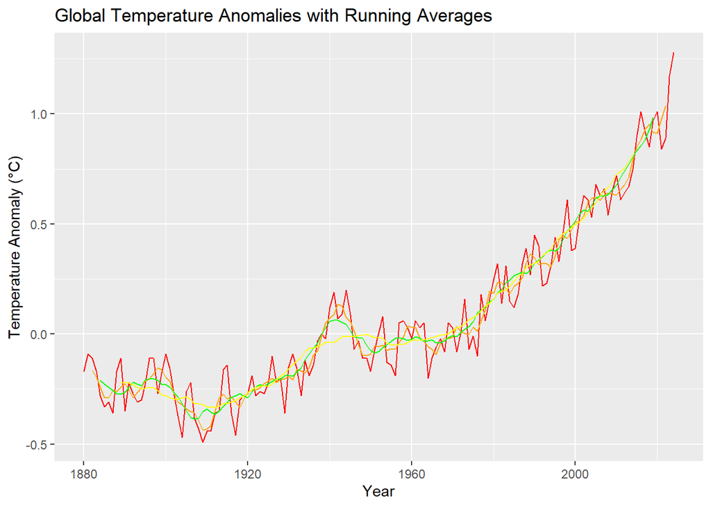

```r
ggplot(global_temp, aes(x = Year)) +
  geom_line(aes(y = No_Smoothing), color = "red") +
  geom_line(aes(y = rolling_avg_5), color = "orange") +
  geom_line(aes(y = rolling_avg_10), color = "green") +
  geom_line(aes(y = rolling_avg_20), color = "yellow") +
  labs(x = "Year", y = "Temperature Anomaly (°C)",
       title = "Global Temperature Anomalies with Running Averages")
```

The variation on the of the data gets less and less as the rolling average gets to a higher year span. The variation gets lower because you are averaging more amounts of data together. **Question 9:**

By examining the data here, what evidence do you find or not find for such a pause?

When analyzing Earth’s climate, it is important to remember that Earth is 4.54 billion years old. Our analyses so far have only looked at recent history. How can we compare the recent data to prehistoric times? Are the current rates of change similar or different from those the earth has experienced in the past? To explore this, we can use data from ice cores drilled at the poles.

Hundreds of ice cores have been extracted from polar ice because they contain valuable data on atmospheric chemistry over pre-historic times. These valuable data exist in tiny air bubbles trapped in the ice. These air bubbles contain the same gases in the same ratios as the atmosphere at the time when the ice formed. The data you will analyze today are from ice cores extracted from the Vostok research station in Antarctica. As you have probably assumed, the depth of the ice core is related to how old the ice is; deep ice is older. There are two other variables that you will be analyzing from the ice cores. You will analyze CO2 concentration, which has been measured from air bubbles trapped in the ice. We can use these data to see what rates of change were like during this pre-historic period, during which human activity was minimal.

[Ice core data](https://data.ess-dive.lbl.gov/view/doi%3A10.3334%2FCDIAC%2FATG.009):

Vostok Core, back to 400,000 years before the present day

- Description of data set: https://data.ess-dive.lbl.gov/view/doi%3A10.3334%2FCDIAC%2FATG.009
- data: https://data.ess-dive.lbl.gov/catalog/d1/mn/v2/object/ess-dive-457358fdc81d3a5-20180726T203952542

You will use this code to download the data to your computer.

```r
download.file("https://data.ess-dive.lbl.gov/catalog/d1/mn/v2/object/ess-dive-457358fdc81d3a5-20180726T203952542",
              destfile = "vostok.icecore.co2")
```

You can click on the file in your Files pane to view it before reading into R.

**Question 10:**

The broad question is: how do recent atmospheric CO2 levels compare to historical levels?

Your answer to Question 10 is going to be a mix of code chunks and text that you put below in “Answer 10:”

- Describe the data set: what are the columns and units? Where do the numbers come from?
- What is the temporal resolution of the data?
- Read in and prepare data for analysis.
- Reverse the ordering to create a chronological record so that each measurement is associcated with calender year.
- Plot data.
- Combine this time series with the Mauna Loa data (the Warm-up exercise in this assignment). You will use “bind_rows()”.
- Plot the combined data. (the most recent time period must be on the right side of the plot).
- Describe your conclusions to the question “How do recent atmospheric CO2 levels compare to historical levels?” using your plot as supporting evidence.

**Answer 10:**

```r
file <- "vostok.icecore.co2"

vostok_co2 <- read_table(file,
                         col_names = c("Depth_m", "Age_Ice_BP", "Age_Air_BP", "CO2_ppm"),
                         col_types = cols(
                           Depth_m = col_double(),
                           Age_Ice_BP = col_integer(),
                           Age_Air_BP = col_integer(),
                           CO2_ppm = col_double()
                         ),
                         skip = 21)

vostok_co2 <- vostok_co2 %>% arrange(Age_Air_BP)
```

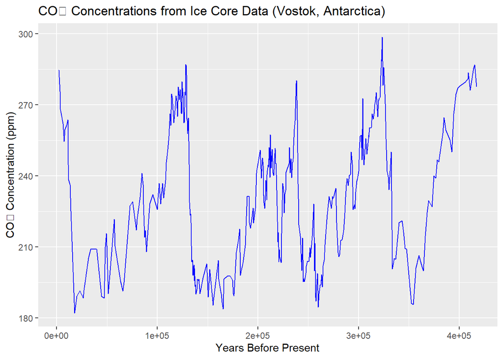

```r
ggplot(vostok_co2, aes(x = Age_Air_BP, y = CO2_ppm)) +
  geom_line(color = "blue") +
  labs(x = "Years Before Present", y = "CO₂ Concentration (ppm)",
       title = "CO₂ Concentrations from Ice Core Data (Vostok, Antarctica)")
```

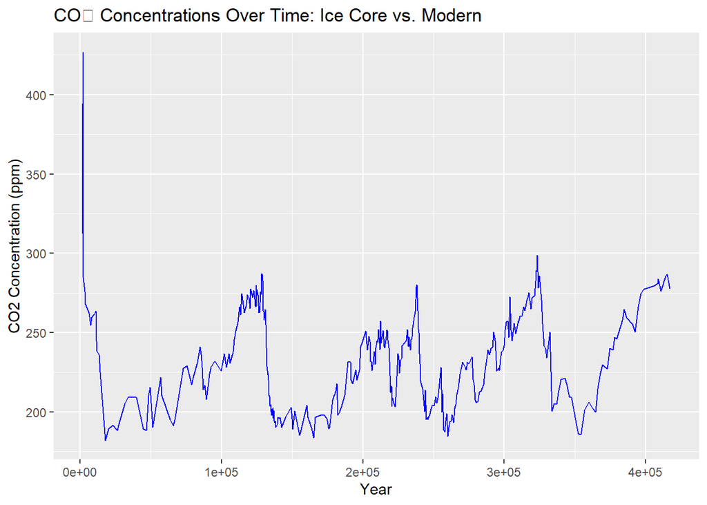

```r
co2_combined <- bind_rows(
  vostok_co2 %>% rename(year = Age_Air_BP, co2_ppm = CO2_ppm),
  co2 %>% select(year, monthly_average) %>% rename(co2_ppm = monthly_average)
)

ggplot(co2_combined, aes(x = year, y = co2_ppm)) +
  geom_line(color = "blue") +
  labs(x = "Year", y = "CO2 Concentration (ppm)",
       title = "CO₂ Concentrations Over Time: Ice Core vs. Modern")
```

The data is historical CO2 concentrations from Vostok ice. The columns are is the depth in meters, the age of the ice sample in years before present, the age of the air sample in years before present, and CO2 concentration in parts per million. The data comes from glacial ice samples in Vostok, Antartica.

The earlier years have lower resolution and the more recent years have better resolution. There are more gaps in the earlier data.

The rate of change is very extreme as you can see from the plots. The conclusion from this is that the massive spike in CO2 levels is human-related with the higher increase closer to the present.

# Render and committing

Remember to Render your document as HTML and comment+push to GitHub your code and rendered HTML that was created when you knitted the document. Your GitHub repository should have multiple commits with informative commit messages.

# Attribution

Include citation of any AI-generated assistance or discussion with classmates (per policy in syllabus). Proper documentation of AI-generated assistance includes the prompt, the source (e.g., ChatGPT), and the significant parts of the response. Proper documentation of discussion with classmates include listing their names and the components discussed.